# MTA data

### 5. Machine Learning — XGBoost Delay Prediction

R² = 0.83 | MAE = 46 delays

```python
# Ml part
df_ml= df.copy()
le_line= LabelEncoder()
le_div= LabelEncoder()
le_cat= LabelEncoder()
df_ml['line_encoded']=le_line.fit_transform(df_ml['line'])
df_ml['division_encoded']= le_div.fit_transform(df_ml['division'])
df_ml['category_encoded']= le_cat.fit_transform(df_ml['reporting_category'])
```

```python
features=['line_encoded', 'division_encoded', 'category_encoded',
            'day_type', 'month_num', 'subway_ridership',
            'bus_ridership', 'subway_vs_prepandemic']
X=df_ml[features]
y=df_ml['delays']
```

```python
X_train, X_test, y_train, y_test=train_test_split(X, y, test_size=0.2, random_state=42)
```

```python
xgb=XGBRegressor(n_estimators=100, random_state=42, verbosity=0)
xgb.fit(X_train, y_train)
```

```
XGBRegressor(base_score=None, booster=None, callbacks=None,
             colsample_bylevel=None, colsample_bynode=None,
             colsample_bytree=None, device=None, early_stopping_rounds=None,
             enable_categorical=False, eval_metric=None, feature_types=None,
             feature_weights=None, gamma=None, grow_policy=None,
             importance_type=None, interaction_constraints=None,
             learning_rate=None, max_bin=None, max_cat_threshold=None,
             max_cat_to_onehot=None, max_delta_step=None, max_depth=None,
             max_leaves=None, min_child_weight=None, missing=nan,
             monotone_constraints=None, multi_strategy=None, n_estimators=100,
             n_jobs=None, num_parallel_tree=None, ...)
```

```python
y_pred=xgb.predict(X_test)
mae=mean_absolute_error(y_test, y_pred)
r2=r2_score(y_test, y_pred)
mape=(abs((y_test.values - y_pred) / y_test.values) * 100).mean()
print(f'MAE:  {mae:,.0f} delays')
print(f'MAPE: {mape:.1f}%')
print(f'R²:   {r2:.3f}')
```

```
MAE:  46 delays
MAPE: 170.3%
R²:   0.827
```

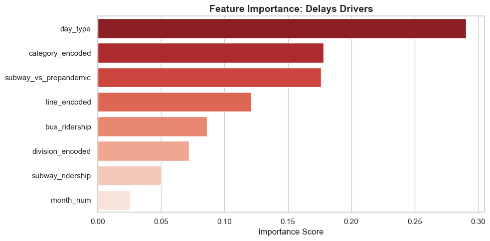

```
Feature Importance:
day_type                 0.291
category_encoded         0.178
subway_vs_prepandemic    0.176
line_encoded             0.121
bus_ridership            0.086
division_encoded         0.072
subway_ridership         0.050
month_num                0.025
dtype: float32
```

```python
importance = pd.Series(xgb.feature_importances_, index=features).sort_values(ascending=False)
plt.figure(figsize=(10,5))
sns.barplot(x=importance.values, y=importance.index, palette='Reds_r')
plt.title('Feature Importance: Delays Drivers', fontsize=14, fontweight='bold')
plt.xlabel('Importance Score')
plt.ylabel('')
plt.tight_layout()
plt.show()
print("\nFeature Importance:")
print(importance.round(3))
```

```python
results = {}

for cat in df_ml['reporting_category'].unique():
    df_cat = df_ml[df_ml['reporting_category'] == cat].copy()

    X = df_cat[['line_encoded', 'division_encoded', 'day_type',
                 'month_num', 'subway_ridership', 'bus_ridership',
                 'subway_vs_prepandemic']]
    y = df_cat['delays']

    X_train, X_test, y_train, y_test = train_test_split(X, y, test_size=0.2, random_state=42)

    model = XGBRegressor(n_estimators=100, random_state=42, verbosity=0)
    model.fit(X_train, y_train)

    y_pred = model.predict(X_test)
    r2 = r2_score(y_test, y_pred)
    mae = mean_absolute_error(y_test, y_pred)

    results[cat] = {'model': model, 'r2': r2, 'mae': mae}
    print(f"{cat}: R²={r2:.3f} MAE={mae:.0f}")
```

```
External Factors: R²=0.517 MAE=22
Operating Conditions: R²=0.813 MAE=39
Infrastructure & Equipment: R²=0.823 MAE=66
Crew Availability: R²=0.843 MAE=39
Police & Medical: R²=0.844 MAE=44
Planned ROW Work: R²=0.781 MAE=59
```

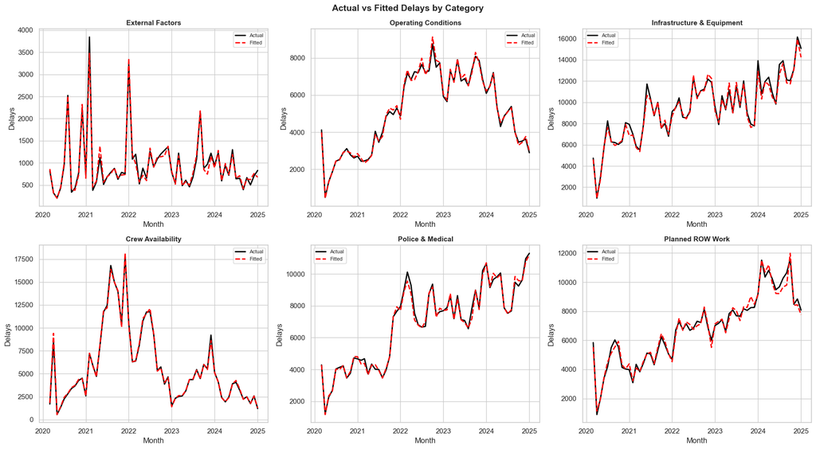

```python
fig, axes=plt.subplots(2, 3, figsize=(18, 10))
axes=axes.flatten()
for idx, cat in enumerate(results.keys()):
    model=results[cat]['model']
    df_cat=df_ml[df_ml['reporting_category']==cat].copy()
    X=df_cat[['line_encoded','division_encoded','day_type',
               'month_num','subway_ridership','bus_ridership','subway_vs_prepandemic']]
    df_cat['fitted']=model.predict(X)
    actual=df_cat.groupby('month')['delays'].sum()
    fitted=df_cat.groupby('month')['fitted'].sum()
    axes[idx].plot(actual.index, actual.values, color='black', label='Actual', linewidth=2)
    axes[idx].plot(fitted.index, fitted.values, color='red', label='Fitted', linewidth=2, linestyle='--')
    axes[idx].set_title(cat, fontsize=11, fontweight='bold')
    axes[idx].set_xlabel('Month')
    axes[idx].set_ylabel('Delays')
    axes[idx].legend(fontsize=8)
plt.suptitle('Actual vs Fitted Delays by Category', fontsize=14, fontweight='bold')
plt.tight_layout()
plt.show()
```

### 6. Per-Category Predictions: Weekday vs Weekend

```python
future_months=pd.date_range(start=df['month'].max(), periods=7, freq='MS')[1:]
for cat in results.keys():
    model=results[cat]['model']
    preds_weekday=[]
    preds_weekend=[]
    for month in future_months:
        X_wd=pd.DataFrame([{
            'line_encoded': df_ml['line_encoded'].mean(),
            'division_encoded': df_ml['division_encoded'].mean(),
            'day_type': 1,
            'month_num': month.month,
            'subway_ridership': df['subway_ridership'].mean(),
            'bus_ridership': df['bus_ridership'].mean(),
            'subway_vs_prepandemic': df['subway_vs_prepandemic'].mean()}])
        X_we=X_wd.copy()
        X_we['day_type']=2
        preds_weekday.append(model.predict(X_wd)[0])
        preds_weekend.append(model.predict(X_we)[0])
    print(f"\n {cat} ")
    for i, month in enumerate(future_months):
        print(f"{month.strftime('%b %Y')} — Weekday: {preds_weekday[i]:.0f} | Weekend: {preds_weekend[i]:.0f}")
```

```
 External Factors
Feb 2025 — Weekday: 45 | Weekend: 14
Mar 2025 — Weekday: 25 | Weekend: -3
Apr 2025 — Weekday: 25 | Weekend: -3
May 2025 — Weekday: 21 | Weekend: -2
Jun 2025 — Weekday: 23 | Weekend: -1
Jul 2025 — Weekday: 16 | Weekend: -1

 Operating Conditions
Feb 2025 — Weekday: 202 | Weekend: 22
Mar 2025 — Weekday: 200 | Weekend: 13
Apr 2025 — Weekday: 211 | Weekend: 20
May 2025 — Weekday: 209 | Weekend: 23
Jun 2025 — Weekday: 206 | Weekend: 20
Jul 2025 — Weekday: 210 | Weekend: 24

 Infrastructure & Equipment
Feb 2025 — Weekday: 359 | Weekend: 65
Mar 2025 — Weekday: 339 | Weekend: 49
Apr 2025 — Weekday: 326 | Weekend: 50
May 2025 — Weekday: 330 | Weekend: 61
Jun 2025 — Weekday: 333 | Weekend: 68
Jul 2025 — Weekday: 366 | Weekend: 81

 Crew Availability
Feb 2025 — Weekday: 198 | Weekend: 192
Mar 2025 — Weekday: 151 | Weekend: 184
Apr 2025 — Weekday: 168 | Weekend: 212
May 2025 — Weekday: 210 | Weekend: 215
Jun 2025 — Weekday: 214 | Weekend: 216
Jul 2025 — Weekday: 281 | Weekend: 200

 Police & Medical
Feb 2025 — Weekday: 174 | Weekend: 70
Mar 2025 — Weekday: 165 | Weekend: 61
Apr 2025 — Weekday: 164 | Weekend: 64
May 2025 — Weekday: 156 | Weekend: 70
Jun 2025 — Weekday: 162 | Weekend: 70
Jul 2025 — Weekday: 162 | Weekend: 72

 Planned ROW Work
Feb 2025 — Weekday: 258 | Weekend: 59
Mar 2025 — Weekday: 262 | Weekend: 61
Apr 2025 — Weekday: 280 | Weekend: 87
May 2025 — Weekday: 295 | Weekend: 96
Jun 2025 — Weekday: 305 | Weekend: 83
Jul 2025 — Weekday: 297 | Weekend: 75
```

## Key Findings

**1. Infrastructure & Equipment causes the most delays** Across all lines and both divisions, this is consistently the biggest problem.

**2. Four lines: N, A, F, and 6, account for 30% of all delays** The system's delay problem is concentrated, not spread evenly.

**3. Weekday delays are 3.5 times higher than weekends** The model confirmed this is the single strongest predictor of how bad delays will be on any given day.

**5. No meaningful seasonality** Delays don't follow a seasonal pattern.

## Recommendations

**1. Add schedule buffer on N, A, F and 6 lines on weekdays** These four lines drive a disproportionate share of delays. That's where timetable adjustments would have the most impact.

**3. Review weekend crew scheduling separately** Crew delays are almost the same on weekdays and weekends. Something specific is happening with weekend staffing worth further analysis.

**4. Use the delay prediction model operationally** With R²=0.83, the XGBoost model is accurate enough to flag high-risk line/day combinations in advance and adjust schedules proactively.